# Clase 3 - Guía de profundización Variables Aleatorias discretas y cualitativas.

Diplomado en Análisis de Datos y Modelamiento Predictivo con Aprendizaje Automático para la Acuicultura.

Dr. José A. Gallardo Matus y Dra. María Angélica Rueda

Pontificia Universidad Católica de Valparaíso  
jose.gallardo@pucv.cl

14 April 2023

### **Introducción**

**¿Cuál es la diferencia entre variable y dato?**

Las **variables** son las características que se pueden medir en un individuo o en un ambiente y los **datos** son los valores que puede tomar esa variable.

**¿Qué es una variable aleatoria?**

Es una variable cuyo valor se determina por el azar. Las variables aleatorias se representan por letras mayúsculas (**X**) y sus valores numéricos por letras minúsculas ($x_i$).

### **Clasificación de variables cuantitativas**

[output not shown]

### **Clasificación de variables cualitativas o categóricas**

| **Tipo de variable** | **Descripción** |
| --- | --- |
| **Variables nominales:** | Sus valores representan categorías que no obedecen a una clasificación intrínseca. |
| **Variables ordinales:** | Sus valores representan categorías con alguna clasificación intrínseca. |

### **Distribuciones posibles para variables aleatorias dicretas**

**Distribución Bernoulli**: la distribución Bernoulli (o distribución dicotómica), nombrada así por el matemático suizo Jacob Bernoulli, es una distribución de probabilidad discreta, donde la variable aleatoria X toma el valor de 1 (**X**=1), cuando ocurre el suceso **éxito** y cuya probabilidad asociada es $p$ y si toma X el valor de cero (**X**=0) ocurre el suceso **fracaso** con probabilidad $q=1-p$. En notación, lo comentado anteriormente sería expresado de la siguiente forma: **P(X=1) =** $p$ (Probabilidad de éxito) y **P(X=0) =** $1-p$ (Probabilidad de fracaso). *Nota*: *La distribución Bernoulli es un caso particular de la distibución binomial cuando* $n=1$, *es decir, solo se hace una vez un ensayo*.

**Distribución Binomial**: la distribución Binomial o distribución binómica es una distribución de probabilidad discreta que cuenta el número de éxitos en una secuencia de $n$ ensayos de Bernoulli independientes entre sí, con una probabilidad fija $p$ de ocurrencia de éxito entre los ensayos y que tiene una probabilidad de fracaso $q=1-p$.

**Distribución binomial negativa**: la distribución Binomial negativa es una distribución de probabilidad discreta que incluye a la distribución de Pascal. Es utilizada en procesos en los cuales se ve necesaria la repetición de ensayos hasta conseguir un número de casos favorables (r-ésimo éxito, es decir, r=2,3,4, etc).

### **¿Cómo puedo simular números aleatorios con distribución Binomial y Bernoulli?**

| **Librería** | **Función** | **Descripción** |
| --- | --- | --- |
| stats | **rbinom(n, size, prob)** | Genera (n) números aleatorios para la distribución binomial con parámetros tamaño (size) y probabilidad de éxito de un ensayo (prob) |
| Rlab | **rbern()** | Simular variable aleatoria Bernoulli |
| MASS | **rnegbin (n, mu, theta)** | Genera (n) números aleatorios para la distribución de binomial negativa con parámetros promedio (mu) y varianza (mu + mu$^{2}$ / theta), donde theta es un número arbitrario para estimar la varianza |

### **¿Cómo puedo observar y predecir el comportamiento de variables con distribución Bernoulli y binomial?**

| **Librería** | **Función** | **Descripción** |
| --- | --- | --- |
| Rlab | **dbern()** | Función de densidad de probabilidad Bernoulli |
| Rlab | **pbern()** | Función de distribución de probabilidad acumulada Bernoulli |
| Rlab | **qbern()** | Función para hallar los cuantiles de una Bernoulli |
| stats | **dbinom()** | Función de densidad de probabilidad Binomial |
| stats | **pbinom()** | Función de distribución de probabilidad acumulada Binomial |
| stats | **qbinom()** | Función para hallar los cuantiles de una Binomial |

### **Objetivos de aprendizaje**

Los objetivos de aprendizaje de esta guía son:

**1**. Observar y predecir el comportamiento de variables aleatorias discretas con distribución Bernoulli, Binomial y binomial negativa.

## **Ejercicios**

### **Ejercicio 1.** **Elaborar un Script de R (Archivo .R)**

Elabore un archivo o file con extensión **.R** usando la barra de herramientas de **Rstudio**. Selecciona **File > New file > R script**. Utilice el siguiente ejemplo para completar la información de **metadatos** del script.

```
# ----------------------------------------------------------
# Clase 03 - Guia Variables Aleatorias discretas y cualitativas.
# Su nombre:
# 15 abril 2023.
# Diplomado en Análisis de Datos y Modelamiento Predictivo con Aprendizaje Automático para la Acuicultura.
# ----------------------------------------------------------
```

Luego, guarde inmediatamente su script como **script_3_nombre_apellido.R**.

### **Ejercicio 2.** **Configuración de librerías**

Debajo del **metadatos** habilite los paquetes **readxl**, **MASS**, **Rlab** usando la función **library()**.

```r
knitr::opts_chunk$set(echo = FALSE)
library(readxl)
library(Rlab)
library(MASS)
```

### **Ejercicio 3.** **Exportación de salmones del Atlántico.**

Una empresa exportadora de salmones del Atlántico implementa un sistema de inspección visual de los salmones, clasificando a un salmón como defectuoso **(D)** y no defectuoso **(ND)**.

**a).** ¿Qué tipo de variable y distribución mejor representaría a la clasificación de un solo salmón como defectuoso o no defectuoso?

```r
# Variable aleatoria discreta con distribución Bernoulli
```

**b).** Si en un proceso de inspección visual se detectó un total de 8 productos defectuosos y 24 no defectuosos. ¿Cuál es la probabilidad *p* de que los productos sean defectuosos?. Use la función paste() para redactar su resultado de forma automática. Use la función round() para redondear el resultado a 2 decimales.

```r
p <- 8 / 32
paste("La proporción de productos defectuosos es = ", round(p,4)*100, "%")
```

```
## [1] "La proporción de productos defectuosos es =  25 %"
```

**c).** ¿Calcule la probabilidad *q* de que los productos no sean defectuosos?

```r
q <- 1-p
paste("La proporción de productos no defectuosos es = ", round(q,4)*100, "%")
```

```
## [1] "La proporción de productos no defectuosos es =  75 %"
```

**d).** El comprador en el extranjero desea determinar el número de productos defectuosos recibidos y establece un acuerdo con el vendedor de revisar en cada lote recibido 3 productos. Note que esta nueva variable es una variable aletoria de tipo discreta que tiene distribución binomial con valores de 0, 1, 2 a 3 productos defectuosos por lote.

Responda las siguientes preguntas usando la información de la siguiente tabla:

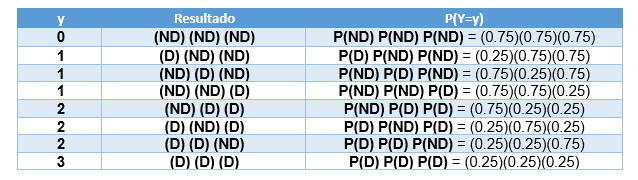

**e).** ¿Cuál es la probabilidad de que el comprador no detecte productos defectuosos (Y = 0)?

```
## [1] "La probabilidad de que no encuentren productos defectuosos es =  42.19 %"
```

**f).** ¿Cuál es la probabilidad de que detecte que todos los productos de la muestra sean defectuoso (Y=3)?

```
## [1] "La probabilidad de que todos los productos de la muestra sean defectuosos es =  1.56 %"
```

### **Ejercicio 4.** **Veneno paralizante de los mariscos.**

*Alexandrium catenella* es una microalga tóxica que produce el veneno paralizante de los mariscos (VPM). En Chile las intoxicaciones por VPM entre 1972-2002 generaron 456 enfermos y 30 fallecidos (total = 486). A partir de estos antecedentes responda.

**a).** ¿Que tipo de variable y distribución mejor representa a la intoxicación por VPM?

```r
# "Variable aleatoria discreta con distribución Binomial"
```

**b).** ¿Calcule la letalidad por VPM en Chile?

```r
LT_VPM <- 30 / 486
LT_VPM
```

```
## [1] 0.0617284
```

**c).** Se ha reportado un intoxicación masiva de veneno paralizante de los mariscos en Calbuco que dio como resultado 80 personas intoxicadas. ¿Cuántas personas se recuperarán (0) y cuantas morirán (1) por esta intoxicación?.

Para responder primero nosotros crearemos para usted un objeto denominado **rvpm** y simularemos el resultado de la intoxicación usando la función **rbinom()**. Usaremos **print()** para observar los datos simulados.

```r
# set.seed function sets the starting number used to generate a sequence of random numbers
set.seed(123)

# n representará el número de intoxicados
n <- 80

# p representará probabilidad de morir con base a datos de letalidad entre 1972 y 2002
p <- 0.0617

# q representa la probabilidad de sobrevivir.
q <- 1-p

# Objeto rvmp contiene la probabilidad de morir = 1 o sobrevivir = 1 para una población simulada de 80 intoxicados.
rvpm <- rbinom(n, size=1, prob=0.0617)

# Explica datos generados
print(rvpm)
```

```
##  [1] 0 0 0 0 1 0 0 0 0 0 1 0 0 0 0 0 0 0 0 1 0 0 0 1 0 0 0 0 0 0 1 0 0 0 0 0 0 0
## [39] 0 0 0 0 0 0 0 0 0 0 0 0 0 0 0 0 0 0 0 0 0 0 0 0 0 0 0 0 0 0 0 0 0 0 0 0 0 0
## [77] 0 0 0 0
```

**d).** Usando la función **table()** represente la frecuencia esperada de recuperados y fallecidos.

```
## rvpm
##  0  1
## 75  5
```

**e).** Represente en un histograma la frecuencia de recuperados y fallecidos.

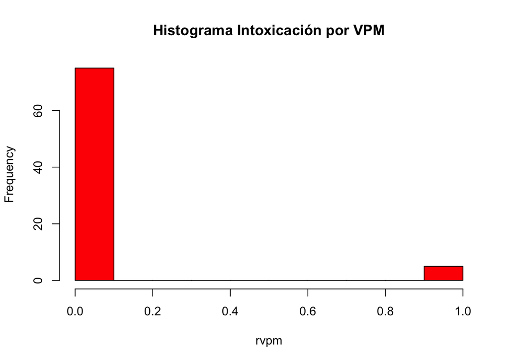

**f).** Investigue como se calcula el promedio y la varianza de una variable con distribución binomial. Calcule ambos parámetros para la población de estudio.

Promedio de fallecidos.

```
## [1] 4.936
```

Varianza de fallecidos.

```
## [1] 4.631449
```

**g).** Cree un objeto llamdo **dvpm** y calcule la función de densidad de los datos simulados rvpm con la función **dbinom()**. Use como argumentos *size=1, prob=0.0617*. Interprete los resultados.

```r
dvpm<-dbinom(rvpm, size=1, prob=0.0617)
dvpm
```

```
##  [1] 0.9383 0.9383 0.9383 0.9383 0.0617 0.9383 0.9383 0.9383 0.9383 0.9383
## [11] 0.0617 0.9383 0.9383 0.9383 0.9383 0.9383 0.9383 0.9383 0.9383 0.0617
## [21] 0.9383 0.9383 0.9383 0.0617 0.9383 0.9383 0.9383 0.9383 0.9383 0.9383
## [31] 0.0617 0.9383 0.9383 0.9383 0.9383 0.9383 0.9383 0.9383 0.9383 0.9383
## [41] 0.9383 0.9383 0.9383 0.9383 0.9383 0.9383 0.9383 0.9383 0.9383 0.9383
## [51] 0.9383 0.9383 0.9383 0.9383 0.9383 0.9383 0.9383 0.9383 0.9383 0.9383
## [61] 0.9383 0.9383 0.9383 0.9383 0.9383 0.9383 0.9383 0.9383 0.9383 0.9383
## [71] 0.9383 0.9383 0.9383 0.9383 0.9383 0.9383 0.9383 0.9383 0.9383 0.9383
```

**h).** Gráfique la función de densidad de las intoxicaciones por VPM usando la función plot. En el eje “x” grafique los datos simulados **rvpm** y en el eje “y” la función de densidad **dvpm**.

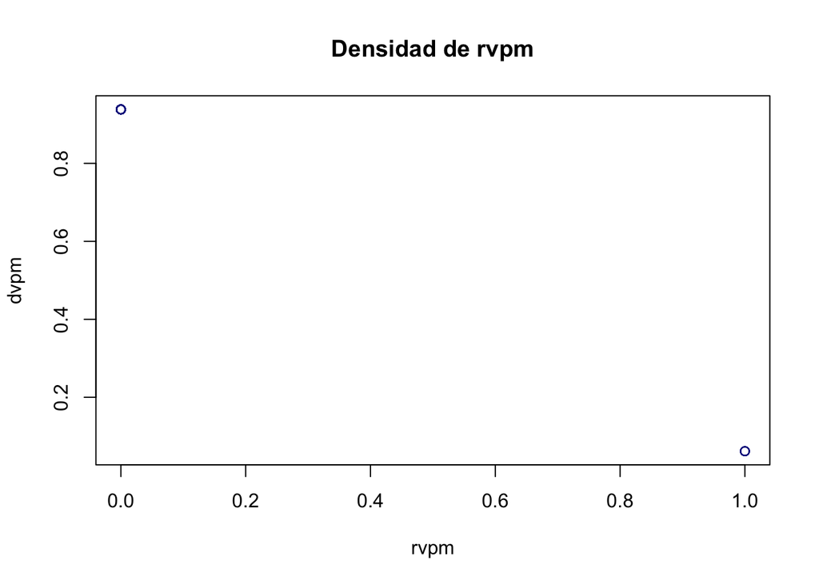

```r
plot(x=rvpm, y=dvpm, main="Densidad de rvpm", col="blue4")
```

**i).** Cree un objeto llamdo **pvpm** y calcule la distribución de probabilidad acumulada de los datos simulados rvpm con la función **pbinom()**. Use como argumentos *size=1, prob=0.0617*. Interprete los resultados.

```
##  [1] 0.9383 0.9383 0.9383 0.9383 1.0000 0.9383 0.9383 0.9383 0.9383 0.9383
## [11] 1.0000 0.9383 0.9383 0.9383 0.9383 0.9383 0.9383 0.9383 0.9383 1.0000
## [21] 0.9383 0.9383 0.9383 1.0000 0.9383 0.9383 0.9383 0.9383 0.9383 0.9383
## [31] 1.0000 0.9383 0.9383 0.9383 0.9383 0.9383 0.9383 0.9383 0.9383 0.9383
## [41] 0.9383 0.9383 0.9383 0.9383 0.9383 0.9383 0.9383 0.9383 0.9383 0.9383
## [51] 0.9383 0.9383 0.9383 0.9383 0.9383 0.9383 0.9383 0.9383 0.9383 0.9383
## [61] 0.9383 0.9383 0.9383 0.9383 0.9383 0.9383 0.9383 0.9383 0.9383 0.9383
## [71] 0.9383 0.9383 0.9383 0.9383 0.9383 0.9383 0.9383 0.9383 0.9383 0.9383
```

**j).** Gráfique la distribución de probabilidad acumulada de las intoxicaciones por VPM usando la función plot(). En el eje “x” grafique los datos simulados**rvpm** y en el eje “y” la probabilidad acumulada **pvpm**.

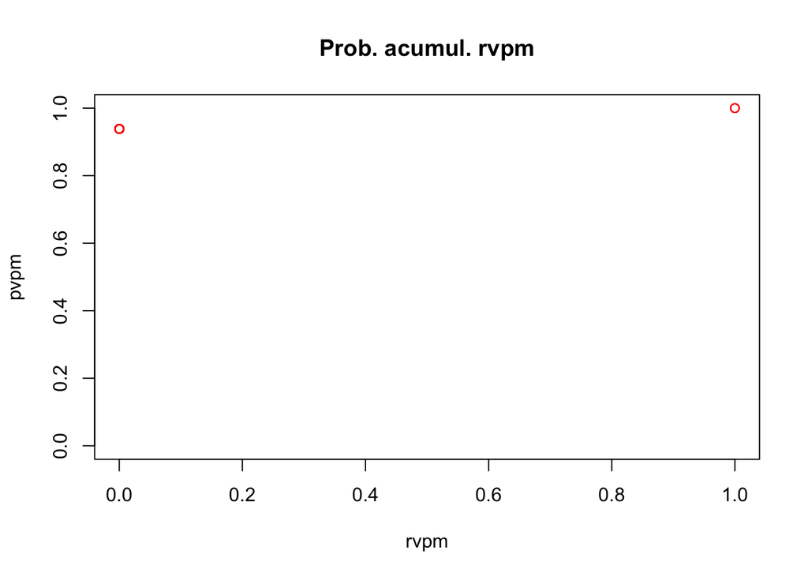